# STOCK PRICE ANALYSIS ON YES BANK

**Team Members:**

1. Mariya Biju (20BDA61)
2. Bismi Joseph (20BDA07)
3. Sruthi Surajan K (20BDA45)

### What is stock market?

The stock market is a market that enables the seamless exchange of buying and selling of company stocks. Every Stock Exchange has its own Stock Index value. The index is the average value that is calculated by combining several stocks. This helps in representing the entire stock market and predicting the market’s movement over time. The stock market can have a huge impact on people and the country’s economy as a whole. Therefore, predicting the stock trends in an efficient manner can minimize the risk of loss and maximize profit.

### How does stock market work?

The concept behind how the stock market works is pretty simple. Operating much like an auction house, the stock market enables buyers and sellers to negotiate prices and make trades.

The stock market works through a network of exchanges — you may have heard of the New York Stock Exchange, Nasdaq or Sensex. Companies list shares of their stock on an exchange through a process called an initial public offering or IPO. Investors purchase those shares, which allows the company to raise money to grow its business. Investors can then buy and sell these stocks among themselves, and the exchange tracks the supply and demand of each listed stock.

That supply and demand help determine the price for each security or the levels at which stock market participants — investors and traders — are willing to buy or sell.

### Why stock price analysis is important?

Performing a research before making an investment is a must. It is only after a thorough research that you can make some assumptions into the value and future performance of an investment. Even if you are following stock trading tips, it ideal to do some research, just to ensure that you are making an investment that’s expected to get you maximum returns.

When you invest in equity, you purchase some portions of a business expecting to make money upon increase in the value of the business. Before buying anything, be it a car or phone, you do some degree of research about its performance and quality. An investment is no different. It is your hard earned money that you are about to invest, so you must have a fair knowledge of what you are investing in.

### YES Bank

Yes Bank Limited is an Indian private sector bank headquartered in Mumbai, India and was founded by Rana Kapoor and Ashok Kapur in 2004. It offers wide range of differentiated products for corporate and retail customers through retail banking and asset management services.On 5 March 2020, in an attempt to avoid the collapse of the bank, which had an excessive amount of bad loans, the Reserve Bank of India (RBI) took control of it.

[figure not shown]

## Problem Statement

The objective of this project is to discuss the rise and fall of 'YES Bank' stock prices and do a stock price analysis.

### Understanding the Data

[figure not shown]

The dataset consists of stock market data of YES Bank and can be downloaded from NSE. It contains data from **2011–01–03** till **2021–12–17**.

   Open: Open means the price at which a stock started trading when the opening bell rang.

   High: High refer to the maximum prices in a given time period.

   Low: Low refer to the minimum prices in a given time period.

   Close: Close refers to the price of an individual stock when the stock exchange closed for the day.
1. There are no missing values in the dataset hence there is no treatment of missing values.

### Loading all the required libraries:

```python
!pip install pmdarima
```

```python
import os
import warnings
warnings.filterwarnings('ignore')
import numpy as np
import pandas as pd
import matplotlib.pyplot as plt
plt.style.use('fivethirtyeight')
from pylab import rcParams
rcParams['figure.figsize'] = 10, 6
from statsmodels.tsa.stattools import adfuller
from statsmodels.tsa.seasonal import seasonal_decompose
from statsmodels.tsa.arima_model import ARIMA
from pmdarima.arima import auto_arima
from sklearn.metrics import mean_squared_error, mean_absolute_error
import math
import numpy as np
```

### Loading the Dataset

```python
dateparse = lambda dates: pd.datetime.strptime(dates, '%Y-%m-%d')
data = pd.read_csv('C:/Users/HP/Downloads/YESBANK1111.csv',sep=',', index_col='Date ', parse_dates=['Date '], date_parser=dateparse).fillna(0)
```

```python
#Data Frame Summary

data.info()
```

```
<class 'pandas.core.frame.DataFrame'>
DatetimeIndex: 2716 entries, 2011-01-03 to 2021-12-17
Data columns (total 7 columns):
 #   Column   Non-Null Count  Dtype
---  ------   --------------  -----
 0   Open     2716 non-null   object
 1   High     2716 non-null   object
 2   Low      2716 non-null   object
 3   ltp      2716 non-null   object
 4   Close    2716 non-null   object
 5   VOLUME   2716 non-null   int64
 6   VALUE    2716 non-null   float64
dtypes: float64(1), int64(1), object(5)
memory usage: 169.8+ KB
```

```python
# converting string dtype to float dtype
data["High"] = [float(str(i).replace(",", "")) for i in data["High"]]
data["Low"] = [float(str(i).replace(",", "")) for i in data["Low"]]
data["Close"] = [float(str(i).replace(",", "")) for i in data["Close"]]
data["Open"] = [float(str(i).replace(",", "")) for i in data["Open"]]
```

```python
data.head()
```

| Date | Open | High | Low | ltp | Close | VOLUME | VALUE |
| --- | --- | --- | --- | --- | --- | --- | --- |
| 2011-01-03 | 13.55 | 13.60 | 13.05 | 13.15 | 13.15 | 111405508 | 1.471523e+09 |
| 2011-01-04 | 13.90 | 14.05 | 13.30 | 13.5 | 13.40 | 122729693 | 1.665063e+09 |
| 2011-01-05 | 13.90 | 14.15 | 13.70 | 13.8 | 13.75 | 113529974 | 1.577815e+09 |
| 2011-01-06 | 13.80 | 14.20 | 13.70 | 13.9 | 13.95 | 137444898 | 1.917956e+09 |
| 2011-01-07 | 14.70 | 14.95 | 13.80 | 13.9 | 14.00 | 255950390 | 3.703242e+09 |

```python
data.tail()
```

| Date | Open | High | Low | ltp | Close | VOLUME | VALUE |
| --- | --- | --- | --- | --- | --- | --- | --- |
| 2021-12-13 | 282.00 | 282.95 | 269.2 | 269.5 | 270.25 | 6885830 | 1.889205e+09 |
| 2021-12-14 | 293.00 | 295.45 | 282.0 | 282.3 | 283.05 | 2473730 | 7.102186e+08 |
| 2021-12-15 | 304.65 | 304.65 | 290.3 | 292 | 291.30 | 3735199 | 1.098476e+09 |
| 2021-12-16 | 316.50 | 317.70 | 305.5 | 305.5 | 306.45 | 1013151 | 3.134909e+08 |
| 2021-12-17 | 315.00 | 316.95 | 314.3 | 314.8 | 315.55 | 1309715 | 4.135571e+08 |

```python
data.info()
```

```
<class 'pandas.core.frame.DataFrame'>
DatetimeIndex: 2716 entries, 2011-01-03 to 2021-12-17
Data columns (total 7 columns):
 #   Column   Non-Null Count  Dtype
---  ------   --------------  -----
 0   Open     2716 non-null   float64
 1   High     2716 non-null   float64
 2   Low      2716 non-null   float64
 3   ltp      2716 non-null   object
 4   Close    2716 non-null   float64
 5   VOLUME   2716 non-null   int64
 6   VALUE    2716 non-null   float64
dtypes: float64(5), int64(1), object(1)
memory usage: 169.8+ KB
```

```python
data.describe(include='all')
```

|  | Open | High | Low | ltp | Close | VOLUME | VALUE |
| --- | --- | --- | --- | --- | --- | --- | --- |
| count | 2716.000000 | 2716.000000 | 2716.000000 | 2716 | 2716.000000 | 2.716000e+03 | 2.716000e+03 |
| unique | NaN | NaN | NaN | 2220 | NaN | NaN | NaN |
| top | NaN | NaN | NaN | 13.15 | NaN | NaN | NaN |
| freq | NaN | NaN | NaN | 11 | NaN | NaN | NaN |
| mean | 464.453351 | 471.278479 | 457.084113 | NaN | 464.162113 | 4.352687e+07 | 3.717585e+09 |
| std | 422.656235 | 427.423271 | 418.209857 | NaN | 423.069376 | 9.661457e+07 | 4.956632e+09 |
| min | 10.800000 | 11.000000 | 5.650000 | NaN | 10.800000 | 1.073330e+05 | 3.744610e+07 |
| 25% | 182.000000 | 184.637500 | 175.512500 | NaN | 180.612500 | 2.315716e+06 | 1.017278e+09 |
| 50% | 341.500000 | 347.700000 | 335.075000 | NaN | 340.775000 | 4.503569e+06 | 2.175177e+09 |
| 75% | 685.100000 | 697.500000 | 671.337500 | NaN | 686.362500 | 3.930123e+07 | 4.045491e+09 |
| max | 1865.000000 | 1886.000000 | 1861.000000 | NaN | 1880.100000 | 1.264918e+09 | 7.212723e+10 |

```python
# checking for duplicate rows
len(data[data.duplicated()])
```

```
0
```

```python
#Count of numerical datatypes
numerical_datatype=['int16','int32','int64','float16','float32','float64']
numeric_df = data.select_dtypes(include=numerical_datatype)
len(numeric_df.columns)
```

```
6
```

```python
#searching for missing value in percentage
missing_percentage=data.isnull().sum().sort_values(ascending=False)/len(data)
missing_percentage
```

```
VALUE      0.0
VOLUME     0.0
Close      0.0
ltp        0.0
Low        0.0
High       0.0
Open       0.0
dtype: float64
```

```python
data.shape
```

```
(2716, 7)
```

### Exploratory Data Analysis

[figure not shown]

```python
data.columns
```

```
Index(['Open', 'High', 'Low', 'ltp ', 'Close', 'VOLUME ', 'VALUE '], dtype='object')
```

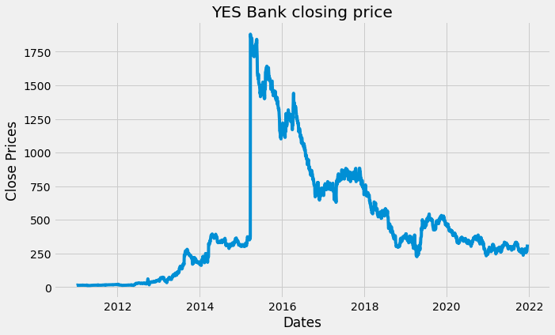

```python
#plot close price
plt.figure(figsize=(10,6))
plt.grid(True)
plt.xlabel('Dates')
plt.ylabel('Close Prices')
plt.plot(data['Close'])
plt.title('YES Bank closing price')
plt.show()
```

Initially the closing price was low between the year 2011 to 2013, then it slightly increases. By the year of 2015 there was a sudden rise in closing price then it falls down and keep a normal trend.

```python
#Find Features with Unique Value
for column in data.columns:
    print(column,data[column].nunique())
```

```
Open 1981
High 2188
Low 2166
ltp  2220
Close 2278
VOLUME  2715
VALUE  2716
```

**Explore the Categorical Features**

```python
categorical_features=[feature for feature in data.columns if ((data[feature].dtypes=='O') & (feature not in ['deposit']))]
categorical_features
```

```
['ltp ']
```

```python
for feature in categorical_features:
    print('The feature {}has {} number of categories '.format(feature,len(data[feature].unique())))
```

```
The feature ltp has 2220 number of categories
```

There is only 1 categorical features 'ltp' with 2220 number of categorical values

**Explore the Numerical Features**

```python
# list of numerical variables
numerical_features = [feature for feature in data.columns if ((data[feature].dtypes != 'O') & (feature not in ['deposit']))]
print('Number of numerical variables: ', len(numerical_features))
```

```
Number of numerical variables:  6
```

```python
discrete_feature=[feature for feature in numerical_features if len(data[feature].unique())<25]
print("Discrete Variables Count: {}".format(len(discrete_feature)))
```

```
Discrete Variables Count: 0
```

There is no Discrete Variables in give dataset

```python
continuous_features=[feature for feature in numerical_features if feature not in discrete_feature+['deposit']]
print("Continuous feature Count {}".format(len(continuous_features)))
```

```
Continuous feature Count 6
```

There are 6 continuous numerical features

**Distribution of Continous Numerical Features**

```python
import seaborn as sns
```

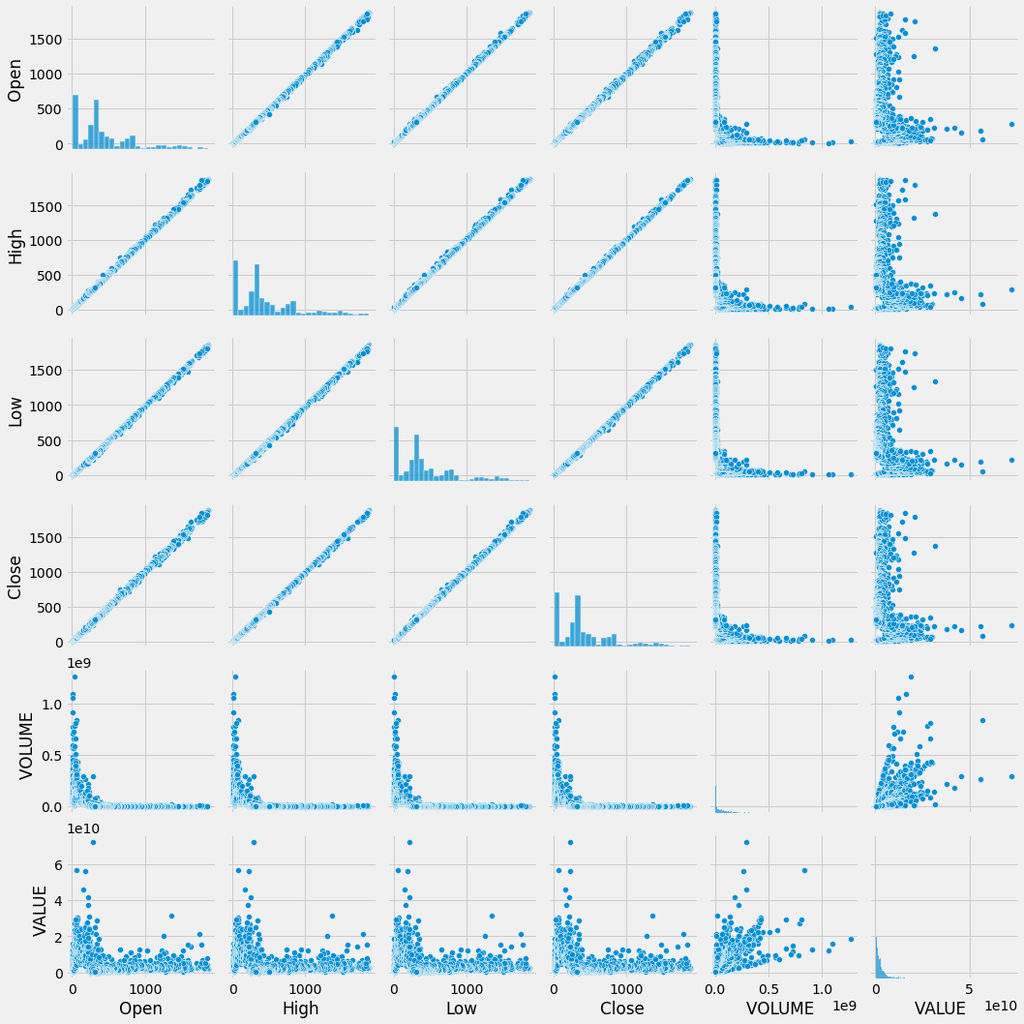

```python
sns.pairplot(data[1:])
```

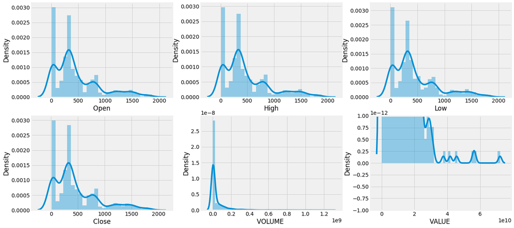

```python
#plot a univariate distribution of continues observations
plt.figure(figsize=(20,60), facecolor='white')
plotnumber =1
for continuous_feature in continuous_features:
    ax = plt.subplot(12,3,plotnumber)
    sns.distplot(data[continuous_feature])
    plt.xlabel(continuous_feature)
    plotnumber+=1
plt.show()
```

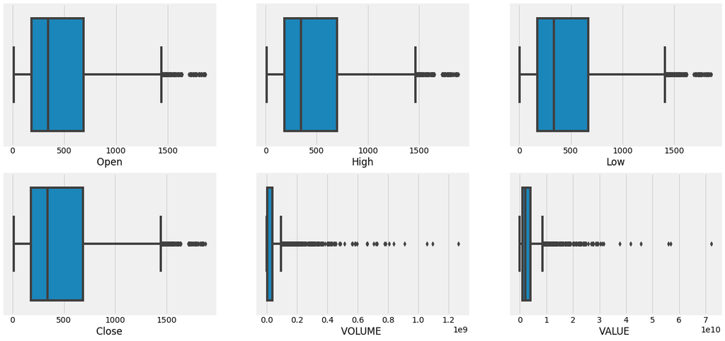

```python
#boxplot on numerical features to find outliers
plt.figure(figsize=(20,60), facecolor='white')
plotnumber =1
for numerical_feature in numerical_features:
    ax = plt.subplot(12,3,plotnumber)
    sns.boxplot(data[numerical_feature])
    plt.xlabel(numerical_feature)
    plotnumber+=1
plt.show()
```

All the features open, high, low, close, volume, value has some outliers.

**Explore the Correlation between numerical features**

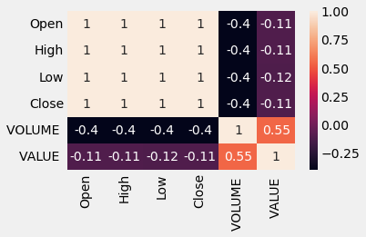

```python
## Checking for correlation
cor_mat=data.corr()
fig = plt.figure(figsize=(5,3))
sns.heatmap(cor_mat,annot=True)
```

It seems that the feature: Open is heavily correlated with other features high, low and close. High is heavily correlated with other features open, low and close. Low is heavily correlated with other features open, high and close. Close is heavily correlated with other features open, high and low.

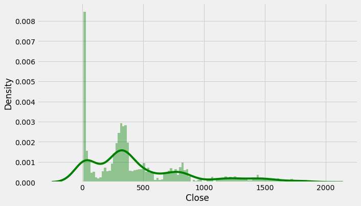

```python
# Distribution plot
sns.distplot(data.loc['2011-01-03':'2021-12-17']['Close'],color='green',bins=100)
```

```python
indep_var=data[['High','Low','Open','VOLUME ']]
dep_var=data['Close']
```

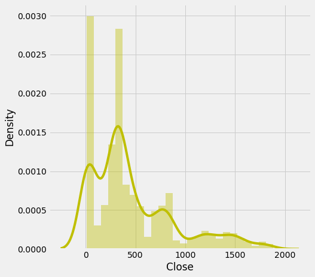

```python
#Dependent variable 'close'
plt.figure(figsize=(7,7))
sns.distplot(dep_var,color="y")
```

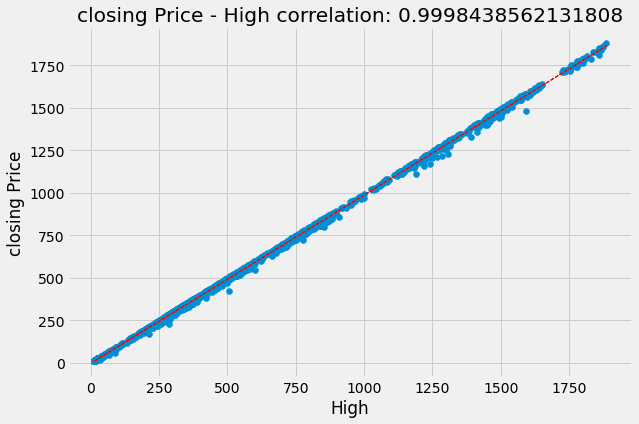

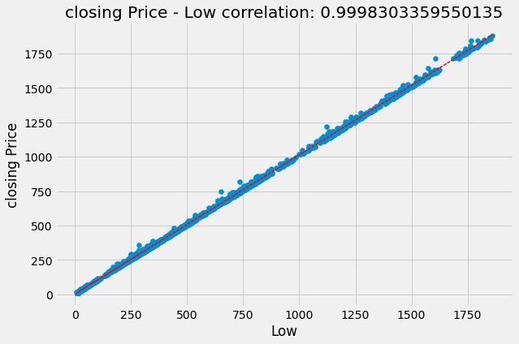

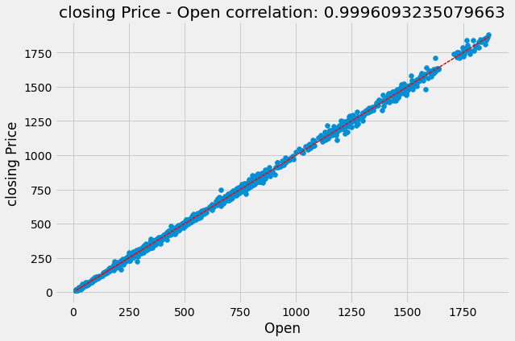

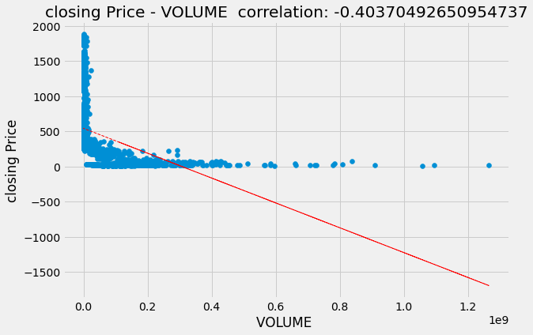

```python
#scatter plot between dependent variable with all independent variables.
for col in indep_var:
   fig = plt.figure(figsize=(9, 6))
   ax = fig.gca()
   feature = data[col]
   label = data['Close']
   correlation = feature.corr(label)
   plt.scatter(x=feature, y=label)
   plt.xlabel(col)
   plt.ylabel('closing Price')
   ax.set_title('closing Price - ' + col + ' correlation: ' + str(correlation))
   z = np.polyfit(data[col], data['Close'], 1)
   y_hat = np.poly1d(z)(data[col])

   plt.plot(data[col], y_hat, "r--", lw=1)

plt.show()
```

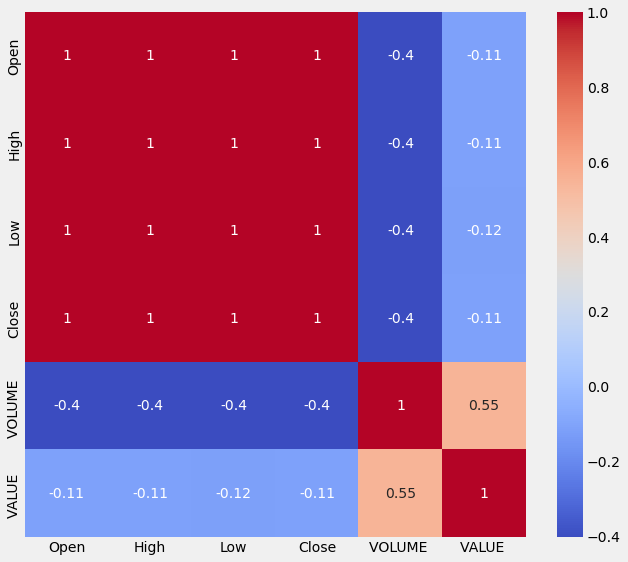

```python
#correlation plot
plt.figure(figsize=(10,9))
sns.heatmap(data.corr(), annot = True, cmap='coolwarm')
plt.show()
```

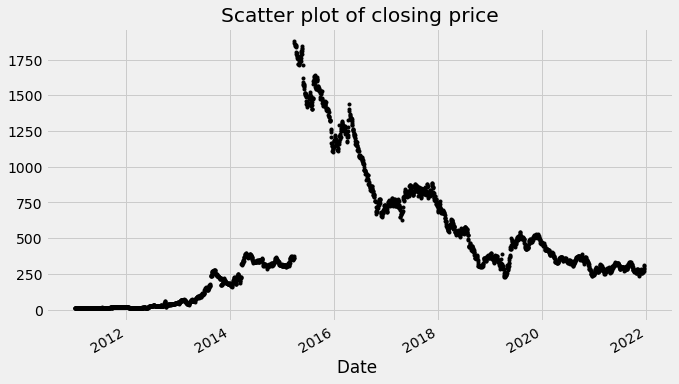

```python
df_close = data['Close']
df_close.plot(style='k.')
plt.title('Scatter plot of closing price')
plt.show()
```

A given time series is thought to consist of three systematic components including level, trend, seasonality, and one non-systematic component called noise. These components are defined as follows:

1. Level: The average value in the series.
2. Trend: The increasing or decreasing value in the series.
3. Seasonality: The repeating short-term cycle in the series.
4. Noise: The random variation in the series.

First, we need to check if a series is stationary or not because time series analysis only works with stationary data.

## TEST FOR STATIONARITY

### ADF (Augmented Dickey-Fuller) Test

The Dickey-Fuller test is one of the most popular statistical tests. It can be used to determine the presence of unit root in the series, and hence help us understand if the series is stationary or not. The null and alternate hypothesis of this test is:

Null Hypothesis: The series has a unit root (value of a =1).

Alternate Hypothesis: The series has no unit root.

If we fail to reject the null hypothesis, we can say that the series is non-stationary. This means that the series can be linear or difference stationary.If both mean and standard deviation are flat lines(constant mean and constant variance), the series becomes stationary.

So let's check for stationarity:

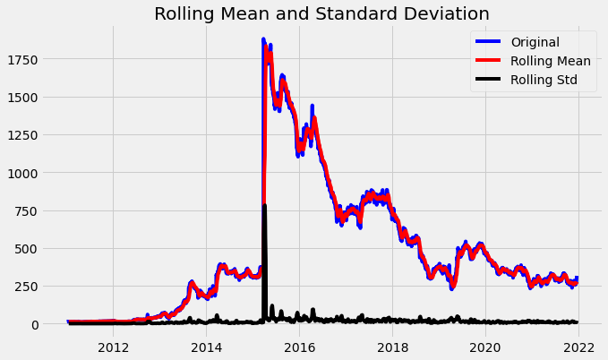

```
Results of dickey fuller test
Test Statistics                  -2.072487
p-value                           0.255721
No. of lags used                  0.000000
Number of observations used    2715.000000
critical value (1%)              -3.432761
critical value (5%)              -2.862605
critical value (10%)             -2.567337
dtype: float64
```

```python
#Test for staionarity
def test_stationarity(timeseries):
    #Determing rolling statistics
    rolmean = timeseries.rolling(12).mean()
    rolstd = timeseries.rolling(12).std()
    #Plot rolling statistics:
    plt.plot(timeseries, color='blue',label='Original')
    plt.plot(rolmean, color='red', label='Rolling Mean')
    plt.plot(rolstd, color='black', label = 'Rolling Std')
    plt.legend(loc='best')
    plt.title('Rolling Mean and Standard Deviation')
    plt.show(block=False)

    print("Results of dickey fuller test")
    adft = adfuller(timeseries,autolag='AIC')
    # output for dft will give us without defining what the values are.
    #hence we manually write what values does it explains using a for loop
    output = pd.Series(adft[0:4],index=['Test Statistics','p-value','No. of lags used','Number of observations used'])
    for key,values in adft[4].items():
        output['critical value (%s)'%key] =  values
    print(output)

test_stationarity(df_close)
```

In order to perform a time series analysis, we may need to separate seasonality and trend from our series. The resultant series will become stationary through this process.

So let us separate Trend and Seasonality from the time series

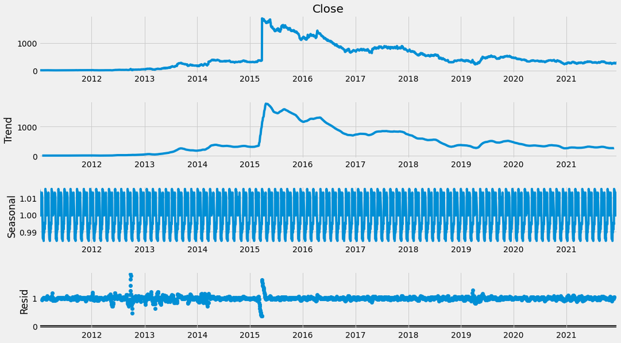

```python
result = seasonal_decompose(df_close, model='multiplicative', freq = 30)
fig = plt.figure()
fig = result.plot()
fig.set_size_inches(16, 9)
```

[output not shown]

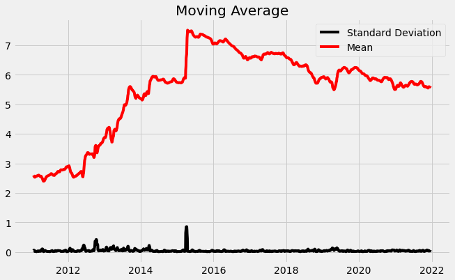

```python
from pylab import rcParams
rcParams['figure.figsize'] = 10, 6
df_log = np.log(df_close)
moving_avg = df_log.rolling(12).mean()
std_dev = df_log.rolling(12).std()
plt.legend(loc='best')
plt.title('Moving Average')
plt.plot(std_dev, color ="black", label = "Standard Deviation")
plt.plot(moving_avg, color="red", label = "Mean")
plt.legend()
plt.show()
```

Now we are going to create an ARIMA model and will train it with the closing price of the stock on the train data. So let us split the data into training and test set and visualize it.

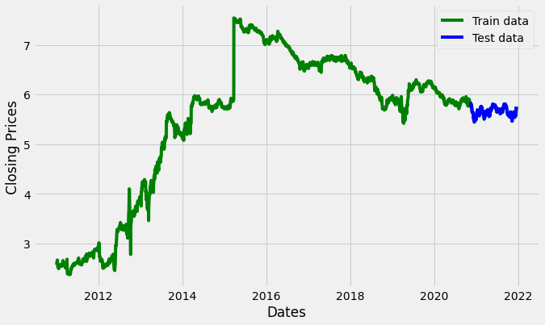

```python
#split data into train and test set
train_data, test_data = df_log[3:int(len(df_log)*0.9)], df_log[int(len(df_log)*0.9):]
plt.figure(figsize=(10,6))
plt.grid(True)
plt.xlabel('Dates')
plt.ylabel('Closing Prices')
plt.plot(df_log, 'green', label='Train data')
plt.plot(test_data, 'blue', label='Test data')
plt.legend()
```

Auto ARIMA: Automatically discover the optimal order for an ARIMA model. The auto_arima function seeks to identify the most optimal parameters for an ARIMA model, and returns a fitted ARIMA model. This function is based on the commonly-used R function, forecast::auto.arima.

The auro_arima function works by conducting differencing tests (i.e., Kwiatkowski–Phillips–Schmidt–Shin, Augmented Dickey-Fuller or Phillips–Perron) to determine the order of differencing, d, and then fitting models within ranges of defined start_p, max_p, start_q, max_q ranges. If the seasonal optional is enabled, auto_arima also seeks to identify the optimal P and Q hyper- parameters after conducting the Canova-Hansen to determine the optimal order of seasonal differencing, D.

```python
model_autoARIMA = auto_arima(train_data, start_p=0, start_q=0,
                      test='adf',       # use adftest to find optimal 'd'
                      max_p=3, max_q=3, # maximum p and q
                      m=1,              # frequency of series
                      d=None,           # let model determine 'd'
                      seasonal=False,   # No Seasonality
                      start_P=0,
                      D=0,
                      trace=True,
                      error_action='ignore',
                      suppress_warnings=True,
                      stepwise=True)
print(model_autoARIMA.summary())
```

```
Performing stepwise search to minimize aic
 ARIMA(0,1,0)(0,0,0)[0] intercept   : AIC=-7506.435, Time=0.46 sec
 ARIMA(1,1,0)(0,0,0)[0] intercept   : AIC=-7505.015, Time=0.62 sec
 ARIMA(0,1,1)(0,0,0)[0] intercept   : AIC=-7505.060, Time=0.36 sec
 ARIMA(0,1,0)(0,0,0)[0]             : AIC=-7506.868, Time=0.15 sec
 ARIMA(1,1,1)(0,0,0)[0] intercept   : AIC=-7504.957, Time=0.85 sec

Best model:  ARIMA(0,1,0)(0,0,0)[0]
Total fit time: 2.732 seconds
                               SARIMAX Results
==============================================================================
Dep. Variable:                      y   No. Observations:                 2441
Model:               SARIMAX(0, 1, 0)   Log Likelihood                3754.434
Date:                Fri, 24 Dec 2021   AIC                          -7506.868
Time:                        12:13:28   BIC                          -7501.068
Sample:                             0   HQIC                         -7504.760
                               - 2441
Covariance Type:                  opg
==============================================================================
                 coef    std err          z      P>|z|      [0.025      0.975]
------------------------------------------------------------------------------
sigma2         0.0027    5.4e-06    499.246      0.000       0.003       0.003
===================================================================================
Ljung-Box (Q):                       42.04   Jarque-Bera (JB):          16799816.01
Prob(Q):                              0.38   Prob(JB):                         0.00
Heteroskedasticity (H):               0.20   Skew:                            13.34
Prob(H) (two-sided):                  0.00   Kurtosis:                       408.63
===================================================================================

Warnings:
[1] Covariance matrix calculated using the outer product of gradients (complex-step).
```

Let’s review the residual plots from auto ARIMA.

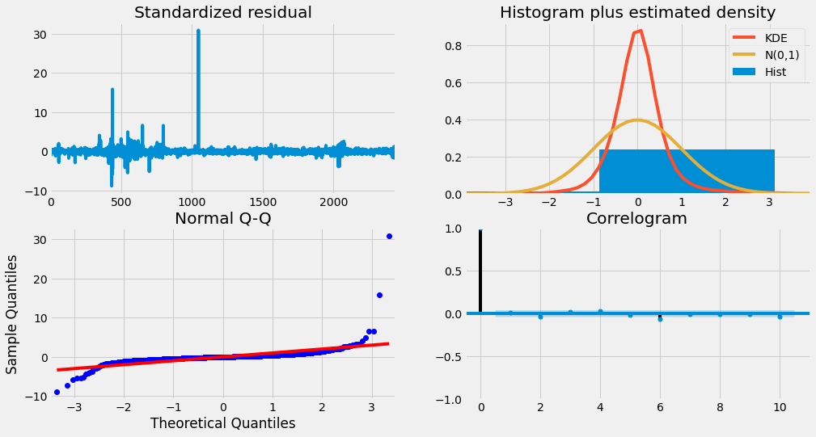

```python
model_autoARIMA.plot_diagnostics(figsize=(15,8))
plt.show()
```

Bottom left: All the dots should fall perfectly in line with the red line. Any significant deviations would imply the distribution is skewed.

Bottom Right: The Correlogram, aka, ACF plot shows the residual errors are not autocorrelated. Any autocorrelation would imply that there is some pattern in the residual errors which are not explained in the model. So you will need to look for more X’s (predictors) to the model.

```python
model = ARIMA(train_data, order=(3, 1, 2))
fitted = model.fit(disp=-1)
print(fitted.summary())
```

```
                             ARIMA Model Results
==============================================================================
Dep. Variable:                D.Close   No. Observations:                 2440
Model:                 ARIMA(3, 1, 2)   Log Likelihood                3763.387
Method:                       css-mle   S.D. of innovations              0.052
Date:                Fri, 24 Dec 2021   AIC                          -7512.773
Time:                        12:13:53   BIC                          -7472.175
Sample:                             1   HQIC                         -7498.016

=================================================================================
                    coef    std err          z      P>|z|      [0.025      0.975]
---------------------------------------------------------------------------------
const             0.0013      0.001      1.230      0.219      -0.001       0.003
ar.L1.D.Close     0.3166      0.093      3.403      0.001       0.134       0.499
ar.L2.D.Close    -0.8604      0.071    -12.040      0.000      -1.000      -0.720
ar.L3.D.Close     0.0488      0.022      2.199      0.028       0.005       0.092
ma.L1.D.Close    -0.3011      0.091     -3.296      0.001      -0.480      -0.122
ma.L2.D.Close     0.8276      0.078     10.601      0.000       0.675       0.981
                                    Roots
=============================================================================
                  Real          Imaginary           Modulus         Frequency
-----------------------------------------------------------------------------
AR.1            0.1531           -1.0767j            1.0876           -0.2275
AR.2            0.1531           +1.0767j            1.0876            0.2275
AR.3           17.3388           -0.0000j           17.3388           -0.0000
MA.1            0.1819           -1.0841j            1.0992           -0.2235
MA.2            0.1819           +1.0841j            1.0992            0.2235
-----------------------------------------------------------------------------
```

Now let's start forecast the stock prices on the test dataset keeping 95% confidence level.

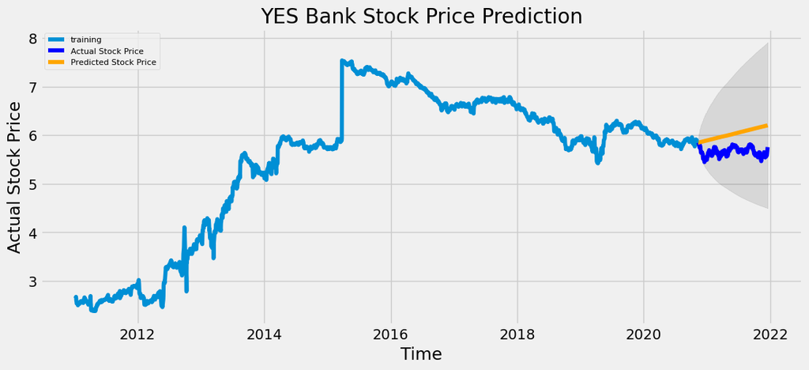

```python
# Forecast
fc, se, conf = fitted.forecast(272, alpha=0.05)  # 95% confidence
fc_series = pd.Series(fc, index=test_data.index)
lower_series = pd.Series(conf[:, 0], index=test_data.index)
upper_series = pd.Series(conf[:, 1], index=test_data.index)
plt.figure(figsize=(12,5), dpi=100)
plt.plot(train_data, label='training')
plt.plot(test_data, color = 'blue', label='Actual Stock Price')
plt.plot(fc_series, color = 'orange',label='Predicted Stock Price')
plt.fill_between(lower_series.index, lower_series, upper_series,
                 color='k', alpha=.10)
plt.title('YES Bank Stock Price Prediction')
plt.xlabel('Time')
plt.ylabel('Actual Stock Price')
plt.legend(loc='upper left', fontsize=8)
plt.show()
```

```python
# report performance
mse = mean_squared_error(test_data, fc)
print('MSE: '+str(mse))
mae = mean_absolute_error(test_data, fc)
print('MAE: '+str(mae))
rmse = math.sqrt(mean_squared_error(test_data, fc))
print('RMSE: '+str(rmse))
mape = np.mean(np.abs(fc - test_data)/np.abs(test_data))
print('MAPE: '+str(mape))
```

```
MSE: 0.15215755814993318
MAE: 0.36804625727428486
RMSE: 0.39007378552003874
MAPE: 0.0652691148889633
```

Around 6.5% MAPE(Mean Absolute Percentage Error) implies the model is about 93.5% accurate in predicting the test set observations.

## CONCLUSION

[figure not shown]

### REFERENCES

1. https://cleartax.in/s/stock-market-analysis
2. https://www.nseindia.com/search?q=yes
3. https://towardsdatascience.com/forecasting-time-series-data-stock-price-analysis-324bcc520af5
4. https://en.wikipedia.org/wiki/Yes_Bank
5. https://towardsdatascience.com/time-series-forecasting-predicting-stock-prices-using-an-arima-model-2e3b3080bd70